# R to Wordpress

Let’s try to build an addin that publish blog posts from R to WordPress.

A useful resource is on the [yihui.name blog](http://rmarkdown.rstudio.com).

## Install needed packages

We need to install the RWordpress package (devtools needed) and the knitr package.

```r
# install.packages('devtools')

# if (!require('RWordPress')) {
#   devtools::install_github(c("duncantl/XMLRPC", "duncantl/RWordPress"))
# }
#
# if(!require('knitr')){
#   install.packages('knitr')
# }
```

Install XML package: failed (Ubuntu)

From [stack overflow](http://stackoverflow.com/questions/7765429/unable-to-install-r-package-in-ubuntu-11-04):

sudo apt-get update sudo apt-get install libxml2-dev

## Enable remote publishing

From the [Codex Wordpress guide](https://codex.wordpress.org/XML-RPC_Support):

> In previous versions of WordPress, XML-RPC was user enabled. To enable, go to Settings > Writing > Remote Publishing and check the checkbox.

To check whether the option is enabled, you need to test the xmlrpc functioning. You can do this by going to your web site URL and adding “/xmlrpc.php” to the end (without the quotes). When it loads in your browser, you should see “XML-RPC server accepts POST requests only.” on a line by itself. If you see something different, [here](https://jetpack.com/support/getting-started-with-jetpack/troubleshooting-tips/) I found some extra useful tips.

## Set login options

From the RWordpress help we can read:

> All the functions require a login and password. This is specified as a named character vector with one element. The value is the password and the name is the login. So we specify this as c(duncan = “mypassword”). Rather than specifying this in each call, we can set the value of the R option WordpressLogin to this vector. By defalt, the functions look there for the login and password.

Then:

```r
# options(WordpressLogin = c(datalamppost = 'rlabtest'),
#        WordpressURL = 'http://www.datalamppost.altervista.org/xmlrpc.php')
```

## Send an html file to wordpress

Here [the function documentation](https://www.rdocumentation.org/packages/knitr/versions/1.15.1/topics/knit2wp):

```r
# setwd()
# knit2wp('Rmd-to-Wordpress-addin.Rmd',
#         title = 'Rmd to WordPress Addin',
#         action = "newPost",
#         publish = F)
```

It worked!!

## Edit a post

Now it’s fun to see if we can edit the post itself. Here is the way:

```r
# knit2wp('Rmd-to-Wordpress-addin.Rmd',
#         title = 'Rmd to WordPress Addin',
#         action = "editPost",
#         postid = 538,
#         publish = F)
```

The post id can be found in the post page itself: [here I found how](https://pagely.com/blog/2015/04/find-post-id-wordpress/)

## Changing ref.label

At the beginning of each chunk there’s a ref.label. We should change it according to the article keyword. [Suggestion here](https://yihui.name/knitr/options/)

## Adding a figure

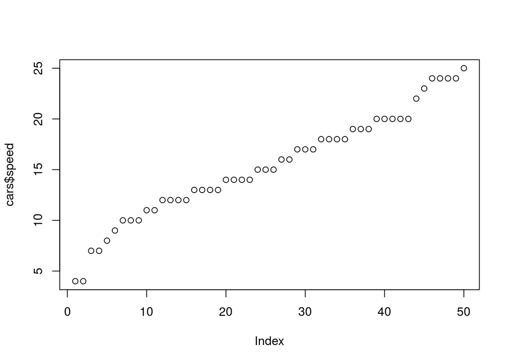

```r
plot(cars$speed)
```

## Notebook options

Add a chuck: *Ctrl+Alt+I*.

Chunk execution: *Ctrl+Shift+Enter*.

Html preview: *Ctrl+Shift+K*.